# Results: st104d01.sas

Stepwise Model Selection for SalePrice - SL 0.05

The GLMSELECT Procedure

| Data Set | STAT1.AMESHOUSING3 |
| --- | --- |
| Dependent Variable | SalePrice |
| Selection Method | Stepwise |
| Select Criterion | Significance Level |
| Stop Criterion | Significance Level |
| Entry Significance Level (SLE) | 0.05 |
| Stay Significance Level (SLS) | 0.05 |
| Effect Hierarchy Enforced | None |

| Number of Observations Read | 300 |
| --- | --- |
| Number of Observations Used | 300 |

| Dimensions |  |
| --- | --- |
| Number of Effects | 9 |
| Number of Parameters | 9 |

Stepwise Model Selection for SalePrice - SL 0.05

The GLMSELECT Procedure

Stepwise Selection: Step 0

Effect Entered: Intercept

| Analysis of Variance Source | Analysis of Variance DF | Analysis of Variance Sum of Squares | Analysis of Variance Mean Square | Analysis of Variance F Value |
| --- | --- | --- | --- | --- |
| Model | 0 | 0 | . | . |
| Error | 299 | 4.232235E11 | 1415463276 |  |
| Corrected Total | 299 | 4.232235E11 |  |  |

| Root MSE | 37623 |
| --- | --- |
| Dependent Mean | 137525 |
| R-Square | 0.0000 |
| Adj R-Sq | 0.0000 |
| AIC | 6624.21515 |
| AICC | 6624.25555 |
| SBC | 6325.91893 |

| Parameter Estimates Parameter | Parameter Estimates DF | Parameter Estimates Estimate | Parameter Estimates Standard Error | Parameter Estimates t Value |
| --- | --- | --- | --- | --- |
| Intercept | 1 | 137525 | 2172.144314 | 63.31 |

Stepwise Model Selection for SalePrice - SL 0.05

The GLMSELECT Procedure

Stepwise Selection: Step 1

Effect Entered: Basement_Area

| Analysis of Variance Source | Analysis of Variance DF | Analysis of Variance Sum of Squares | Analysis of Variance Mean Square | Analysis of Variance F Value |
| --- | --- | --- | --- | --- |
| Model | 1 | 2.012418E11 | 2.012418E11 | 270.16 |
| Error | 298 | 2.219817E11 | 744904950 |  |
| Corrected Total | 299 | 4.232235E11 |  |  |

| Root MSE | 27293 |
| --- | --- |
| Dependent Mean | 137525 |
| R-Square | 0.4755 |
| Adj R-Sq | 0.4737 |
| AIC | 6432.62346 |
| AICC | 6432.70454 |
| SBC | 6138.03102 |

| Parameter Estimates Parameter | Parameter Estimates DF | Parameter Estimates Estimate | Parameter Estimates Standard Error | Parameter Estimates t Value |
| --- | --- | --- | --- | --- |
| Intercept | 1 | 73904 | 4179.193780 | 17.68 |
| Basement_Area | 1 | 72.107717 | 4.387055 | 16.44 |

| Entry Candidates Rank | Entry Candidates Effect | Entry Candidates Log pValue | Entry Candidates Pr > F |
| --- | --- | --- | --- |
| 1 | Basement_Area | -98.8577 | <.0001 |
| 2 | Gr_Liv_Area | -84.6132 | <.0001 |
| 3 | Age_Sold | -73.5219 | <.0001 |
| 4 | Total_Bathroom | -69.1880 | <.0001 |
| 5 | Garage_Area | -63.3558 | <.0001 |
| 6 | Deck_Porch_Area | -34.3105 | <.0001 |
| 7 | Lot_Area | -11.6303 | <.0001 |
| 8 | Bedroom_AbvGr | -5.5339 | 0.0040 |

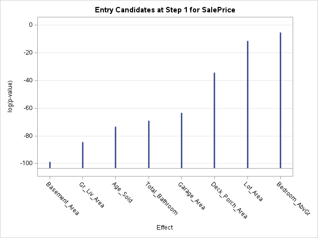

Stepwise Model Selection for SalePrice - SL 0.05

The GLMSELECT Procedure

Stepwise Selection: Step 2

Effect Entered: Gr_Liv_Area

| Analysis of Variance Source | Analysis of Variance DF | Analysis of Variance Sum of Squares | Analysis of Variance Mean Square | Analysis of Variance F Value |
| --- | --- | --- | --- | --- |
| Model | 2 | 2.64483E11 | 1.322415E11 | 247.42 |
| Error | 297 | 1.587405E11 | 534479711 |  |
| Corrected Total | 299 | 4.232235E11 |  |  |

| Root MSE | 23119 |
| --- | --- |
| Dependent Mean | 137525 |
| R-Square | 0.6249 |
| Adj R-Sq | 0.6224 |
| AIC | 6334.02620 |
| AICC | 6334.16179 |
| SBC | 6043.13755 |

| Parameter Estimates Parameter | Parameter Estimates DF | Parameter Estimates Estimate | Parameter Estimates Standard Error | Parameter Estimates t Value |
| --- | --- | --- | --- | --- |
| Intercept | 1 | 12664 | 6650.339855 | 1.90 |
| Gr_Liv_Area | 1 | 69.606974 | 6.399091 | 10.88 |
| Basement_Area | 1 | 52.309702 | 4.137885 | 12.64 |

| Entry Candidates Rank | Entry Candidates Effect | Entry Candidates Log pValue | Entry Candidates Pr > F |
| --- | --- | --- | --- |
| 1 | Gr_Liv_Area | -52.2496 | <.0001 |
| 2 | Age_Sold | -48.2636 | <.0001 |
| 3 | Garage_Area | -43.6174 | <.0001 |
| 4 | Total_Bathroom | -31.0375 | <.0001 |
| 5 | Deck_Porch_Area | -16.3568 | <.0001 |
| 6 | Lot_Area | -2.2708 | 0.1032 |
| 7 | Bedroom_AbvGr | -0.7570 | 0.4691 |

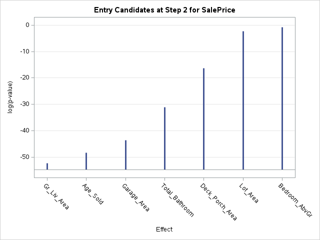

Stepwise Model Selection for SalePrice - SL 0.05

The GLMSELECT Procedure

Stepwise Selection: Step 3

Effect Entered: Age_Sold

| Analysis of Variance Source | Analysis of Variance DF | Analysis of Variance Sum of Squares | Analysis of Variance Mean Square | Analysis of Variance F Value |
| --- | --- | --- | --- | --- |
| Model | 3 | 3.207148E11 | 1.069049E11 | 308.69 |
| Error | 296 | 1.025087E11 | 346313132 |  |
| Corrected Total | 299 | 4.232235E11 |  |  |

| Root MSE | 18609 |
| --- | --- |
| Dependent Mean | 137525 |
| R-Square | 0.7578 |
| Adj R-Sq | 0.7553 |
| AIC | 6204.82927 |
| AICC | 6205.03335 |
| SBC | 5917.64440 |

| Parameter Estimates Parameter | Parameter Estimates DF | Parameter Estimates Estimate | Parameter Estimates Standard Error | Parameter Estimates t Value |
| --- | --- | --- | --- | --- |
| Intercept | 1 | 53400 | 6235.076995 | 8.56 |
| Gr_Liv_Area | 1 | 68.106646 | 5.152294 | 13.22 |
| Basement_Area | 1 | 36.329120 | 3.559067 | 10.21 |
| Age_Sold | 1 | -543.493346 | 42.651840 | -12.74 |

| Entry Candidates Rank | Entry Candidates Effect | Entry Candidates Log pValue | Entry Candidates Pr > F |
| --- | --- | --- | --- |
| 1 | Age_Sold | -67.2828 | <.0001 |
| 2 | Garage_Area | -37.5122 | <.0001 |
| 3 | Total_Bathroom | -21.6266 | <.0001 |
| 4 | Deck_Porch_Area | -12.5097 | <.0001 |
| 5 | Bedroom_AbvGr | -12.4446 | <.0001 |
| 6 | Lot_Area | -0.4524 | 0.6361 |

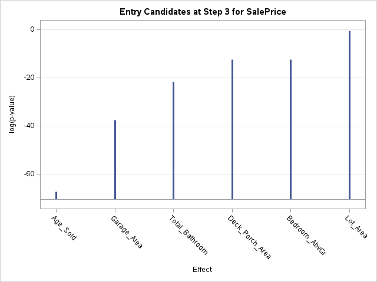

Stepwise Model Selection for SalePrice - SL 0.05

The GLMSELECT Procedure

Stepwise Selection: Step 4

Effect Entered: Garage_Area

| Analysis of Variance Source | Analysis of Variance DF | Analysis of Variance Sum of Squares | Analysis of Variance Mean Square | Analysis of Variance F Value |
| --- | --- | --- | --- | --- |
| Model | 4 | 3.33571E11 | 83392754480 | 274.40 |
| Error | 295 | 89652501590 | 303906785 |  |
| Corrected Total | 299 | 4.232235E11 |  |  |

| Root MSE | 17433 |
| --- | --- |
| Dependent Mean | 137525 |
| R-Square | 0.7882 |
| Adj R-Sq | 0.7853 |
| AIC | 6166.62734 |
| AICC | 6166.91403 |
| SBC | 5883.14625 |

| Parameter Estimates Parameter | Parameter Estimates DF | Parameter Estimates Estimate | Parameter Estimates Standard Error | Parameter Estimates t Value |
| --- | --- | --- | --- | --- |
| Intercept | 1 | 43815 | 6023.907004 | 7.27 |
| Gr_Liv_Area | 1 | 61.238136 | 4.940722 | 12.39 |
| Basement_Area | 1 | 33.430181 | 3.363709 | 9.94 |
| Garage_Area | 1 | 42.984492 | 6.608851 | 6.50 |
| Age_Sold | 1 | -455.704354 | 42.173481 | -10.81 |

| Entry Candidates Rank | Entry Candidates Effect | Entry Candidates Log pValue | Entry Candidates Pr > F |
| --- | --- | --- | --- |
| 1 | Garage_Area | -21.8203 | <.0001 |
| 2 | Deck_Porch_Area | -12.9294 | <.0001 |
| 3 | Bedroom_AbvGr | -7.8057 | 0.0004 |
| 4 | Total_Bathroom | -3.8856 | 0.0205 |
| 5 | Lot_Area | -3.6980 | 0.0248 |

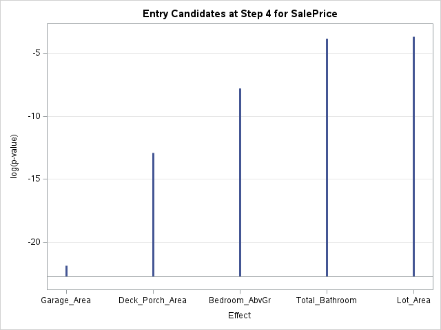

Stepwise Model Selection for SalePrice - SL 0.05

The GLMSELECT Procedure

Stepwise Selection: Step 5

Effect Entered: Deck_Porch_Area

| Analysis of Variance Source | Analysis of Variance DF | Analysis of Variance Sum of Squares | Analysis of Variance Mean Square | Analysis of Variance F Value |
| --- | --- | --- | --- | --- |
| Model | 5 | 3.392788E11 | 67855752389 | 237.65 |
| Error | 294 | 83944757568 | 285526386 |  |
| Corrected Total | 299 | 4.232235E11 |  |  |

| Root MSE | 16898 |
| --- | --- |
| Dependent Mean | 137525 |
| R-Square | 0.8017 |
| Adj R-Sq | 0.7983 |
| AIC | 6148.89269 |
| AICC | 6149.27625 |
| SBC | 5869.11538 |

| Parameter Estimates Parameter | Parameter Estimates DF | Parameter Estimates Estimate | Parameter Estimates Standard Error | Parameter Estimates t Value |
| --- | --- | --- | --- | --- |
| Intercept | 1 | 46009 | 5859.485517 | 7.85 |
| Gr_Liv_Area | 1 | 58.386514 | 4.831268 | 12.09 |
| Basement_Area | 1 | 30.554240 | 3.323249 | 9.19 |
| Garage_Area | 1 | 40.158112 | 6.436997 | 6.24 |
| Deck_Porch_Area | 1 | 35.720258 | 7.989240 | 4.47 |
| Age_Sold | 1 | -447.254040 | 40.921927 | -10.93 |

| Entry Candidates Rank | Entry Candidates Effect | Entry Candidates Log pValue | Entry Candidates Pr > F |
| --- | --- | --- | --- |
| 1 | Deck_Porch_Area | -11.4060 | <.0001 |
| 2 | Bedroom_AbvGr | -6.2737 | 0.0019 |
| 3 | Total_Bathroom | -3.1045 | 0.0448 |
| 4 | Lot_Area | -1.9476 | 0.1426 |

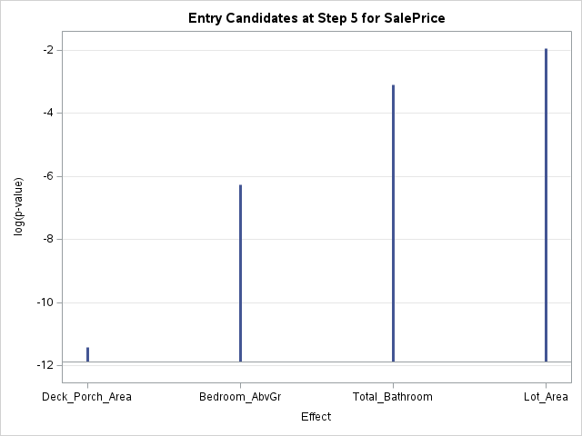

Stepwise Model Selection for SalePrice - SL 0.05

The GLMSELECT Procedure

Stepwise Selection: Step 6

Effect Entered: Bedroom_AbvGr

| Analysis of Variance Source | Analysis of Variance DF | Analysis of Variance Sum of Squares | Analysis of Variance Mean Square | Analysis of Variance F Value |
| --- | --- | --- | --- | --- |
| Model | 6 | 3.410749E11 | 56845818595 | 202.75 |
| Error | 293 | 82148607939 | 280370676 |  |
| Corrected Total | 299 | 4.232235E11 |  |  |

| Root MSE | 16744 |
| --- | --- |
| Dependent Mean | 137525 |
| R-Square | 0.8059 |
| Adj R-Sq | 0.8019 |
| AIC | 6144.40398 |
| AICC | 6144.89882 |
| SBC | 5868.33046 |

| Parameter Estimates Parameter | Parameter Estimates DF | Parameter Estimates Estimate | Parameter Estimates Standard Error | Parameter Estimates t Value |
| --- | --- | --- | --- | --- |
| Intercept | 1 | 48620 | 5897.324643 | 8.24 |
| Gr_Liv_Area | 1 | 65.097413 | 5.472624 | 11.90 |
| Basement_Area | 1 | 31.279351 | 3.305546 | 9.46 |
| Garage_Area | 1 | 38.728785 | 6.403565 | 6.05 |
| Deck_Porch_Area | 1 | 32.487956 | 8.019119 | 4.05 |
| Age_Sold | 1 | -434.199118 | 40.877494 | -10.62 |
| Bedroom_AbvGr | 1 | -4189.095026 | 1655.065743 | -2.53 |

| Entry Candidates Rank | Entry Candidates Effect | Entry Candidates Log pValue | Entry Candidates Pr > F |
| --- | --- | --- | --- |
| 1 | Bedroom_AbvGr | -4.4317 | 0.0119 |
| 2 | Total_Bathroom | -2.5664 | 0.0768 |
| 3 | Lot_Area | -2.1476 | 0.1168 |

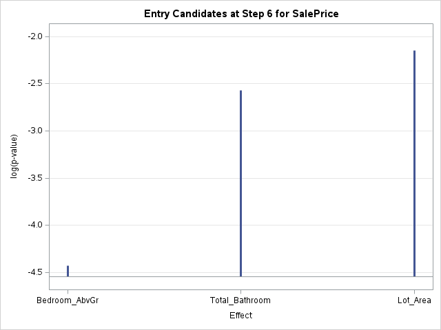

Stepwise Model Selection for SalePrice - SL 0.05

The GLMSELECT Procedure

Stepwise Selection: Step 7

Effect Entered: Lot_Area

| Analysis of Variance Source | Analysis of Variance DF | Analysis of Variance Sum of Squares | Analysis of Variance Mean Square | Analysis of Variance F Value |
| --- | --- | --- | --- | --- |
| Model | 7 | 3.424508E11 | 48921543221 | 176.86 |
| Error | 292 | 80772716963 | 276618894 |  |
| Corrected Total | 299 | 4.232235E11 |  |  |

| Root MSE | 16632 |
| --- | --- |
| Dependent Mean | 137525 |
| R-Square | 0.8091 |
| Adj R-Sq | 0.8046 |
| AIC | 6141.33678 |
| AICC | 6141.95747 |
| SBC | 5868.96704 |

| Parameter Estimates Parameter | Parameter Estimates DF | Parameter Estimates Estimate | Parameter Estimates Standard Error | Parameter Estimates t Value |
| --- | --- | --- | --- | --- |
| Intercept | 1 | 47463 | 5880.674041 | 8.07 |
| Gr_Liv_Area | 1 | 65.303724 | 5.436672 | 12.01 |
| Basement_Area | 1 | 29.849078 | 3.345400 | 8.92 |
| Garage_Area | 1 | 36.309606 | 6.452405 | 5.63 |
| Deck_Porch_Area | 1 | 32.052554 | 7.967677 | 4.02 |
| Lot_Area | 1 | 0.708127 | 0.317512 | 2.23 |
| Age_Sold | 1 | -447.198682 | 41.019314 | -10.90 |
| Bedroom_AbvGr | 1 | -5042.766498 | 1687.928168 | -2.99 |

| Entry Candidates Rank | Entry Candidates Effect | Entry Candidates Log pValue | Entry Candidates Pr > F |
| --- | --- | --- | --- |
| 1 | Lot_Area | -3.6309 | 0.0265 |
| 2 | Total_Bathroom | -2.2036 | 0.1104 |

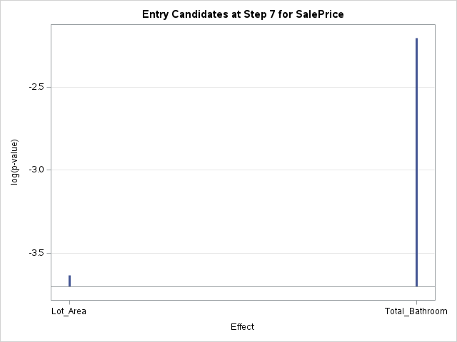

Stepwise Model Selection for SalePrice - SL 0.05

The GLMSELECT Procedure

| Stepwise Selection Summary Step | Stepwise Selection Summary Effect Entered | Stepwise Selection Summary Effect Removed | Stepwise Selection Summary Number Effects In | Stepwise Selection Summary F Value | Stepwise Selection Summary Pr > F |
| --- | --- | --- | --- | --- | --- |
| 0 | Intercept |  | 1 | 0.00 | 1.0000 |
| 1 | Basement_Area |  | 2 | 270.16 | <.0001 |
| 2 | Gr_Liv_Area |  | 3 | 118.32 | <.0001 |
| 3 | Age_Sold |  | 4 | 162.37 | <.0001 |
| 4 | Garage_Area |  | 5 | 42.30 | <.0001 |
| 5 | Deck_Porch_Area |  | 6 | 19.99 | <.0001 |
| 6 | Bedroom_AbvGr |  | 7 | 6.41 | 0.0119 |
| 7 | Lot_Area |  | 8 | 4.97 | 0.0265 |

| Selection stopped because the candidate for entry has SLE > 0.05 and the candidate for removal has SLS < 0.05. |
| --- |

[output not shown]

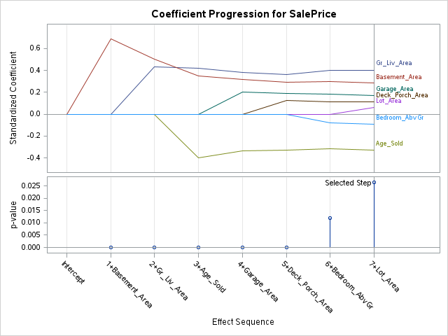

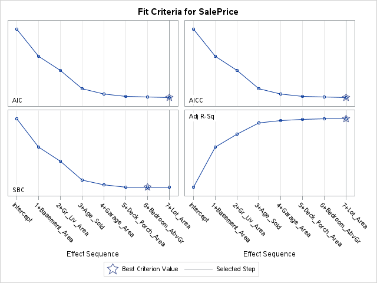

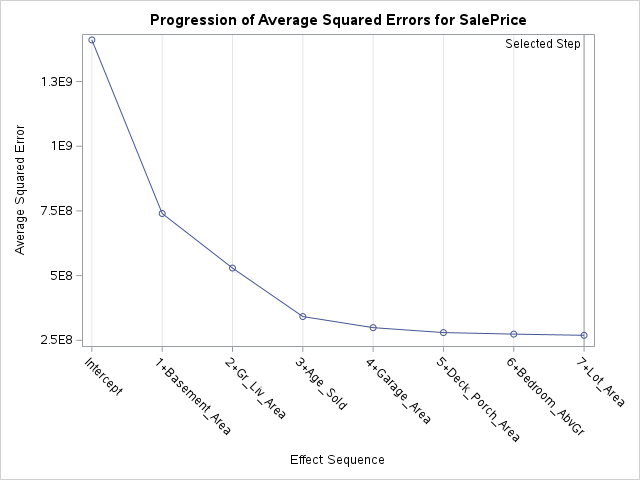

Stepwise Model Selection for SalePrice - SL 0.05

The GLMSELECT Procedure

Selected Model

The selected model is the model at the last step (Step 7).

| Effects: | Intercept Gr_Liv_Area Basement_Area Garage_Area Deck_Porch_Area Lot_Area Age_Sold Bedroom_AbvGr |
| --- | --- |

| Analysis of Variance Source | Analysis of Variance DF | Analysis of Variance Sum of Squares | Analysis of Variance Mean Square | Analysis of Variance F Value |
| --- | --- | --- | --- | --- |
| Model | 7 | 3.424508E11 | 48921543221 | 176.86 |
| Error | 292 | 80772716963 | 276618894 |  |
| Corrected Total | 299 | 4.232235E11 |  |  |

| Root MSE | 16632 |
| --- | --- |
| Dependent Mean | 137525 |
| R-Square | 0.8091 |
| Adj R-Sq | 0.8046 |
| AIC | 6141.33678 |
| AICC | 6141.95747 |
| SBC | 5868.96704 |

| Parameter Estimates Parameter | Parameter Estimates DF | Parameter Estimates Estimate | Parameter Estimates Standard Error | Parameter Estimates t Value |
| --- | --- | --- | --- | --- |
| Intercept | 1 | 47463 | 5880.674041 | 8.07 |
| Gr_Liv_Area | 1 | 65.303724 | 5.436672 | 12.01 |
| Basement_Area | 1 | 29.849078 | 3.345400 | 8.92 |
| Garage_Area | 1 | 36.309606 | 6.452405 | 5.63 |
| Deck_Porch_Area | 1 | 32.052554 | 7.967677 | 4.02 |
| Lot_Area | 1 | 0.708127 | 0.317512 | 2.23 |
| Age_Sold | 1 | -447.198682 | 41.019314 | -10.90 |
| Bedroom_AbvGr | 1 | -5042.766498 | 1687.928168 | -2.99 |